# INFORME - SEGUROS VEHICULOS - TRABAJO GRUPAL

MÓNICA DANIELA BARREIRO LINZÁN, ENZO YESANCE SÁNCHEZ TANG, NESTOR EDISON IBARRA FLORES

2026-09-23

# Introducción

El sector asegurador automotriz requiere evaluar constantemente la siniestralidad de sus pólizas para ajustar tarifas, predecir pérdidas y detectar perfiles de riesgo elevado. El presente informe desarrolla una auditoría integral de datos sobre el conjunto `Seguros_Vehiculos`, compuesto por información demográfica, socioeconómica y de historial conductivo de 65,000 asegurados, estructurando transformaciones complejas de variables y generando visualizaciones efectivas para la toma de decisiones gerenciales.

El análisis se organiza en tres fases: (1) tratamiento, limpieza y calidad de datos; (2) manipulación, agregación y métricas de siniestralidad; y (3) visualización de datos e insights visuales.

```r
head(data)
```

```
## # A tibble: 6 × 23
##      Id ConducenHijos  Edad NHijos AntiguedadTrabajo Ingresos Soltero
##   <dbl>         <dbl> <dbl>  <dbl>             <dbl> <chr>    <chr>
## 1 18788             0    42      0                11 $61,530  No
## 2 62750             0    58      0                10 $153,831 No
## 3 78225             0    52      0                 6 $86,498  No
## 4 54934             0    32      1                 5 $68,288  No
## 5 76545             0    40      3                17 $96,169  No
## 6 85814             0    50      0                 8 $43,379  No
## # ℹ 16 more variables: ValorDomicilio <chr>, Genero <chr>, Educacion <chr>,
## #   Trabajo <chr>, DistanciaTrabajo <dbl>, Uso <chr>, ValVehiculo <chr>,
## #   Experiencia <dbl>, Tipo <chr>, ColorRojo <chr>, TCuantia <chr>,
## #   NSiniestros <dbl>, Suspensiones <chr>, Motor <dbl>, Antiguedad <dbl>,
## #   Zona <chr>
```

```r
str(data)
```

```
## spc_tbl_ [65,000 × 23] (S3: spec_tbl_df/tbl_df/tbl/data.frame)
##  $ Id               : num [1:65000] 18788 62750 78225 54934 76545 ...
##  $ ConducenHijos    : num [1:65000] 0 0 0 0 0 0 0 0 1 0 ...
##  $ Edad             : num [1:65000] 42 58 52 32 40 50 34 55 59 53 ...
##  $ NHijos           : num [1:65000] 0 0 0 1 3 0 1 0 1 0 ...
##  $ AntiguedadTrabajo: num [1:65000] 11 10 6 5 17 8 12 8 12 15 ...
##  $ Ingresos         : chr [1:65000] "$61,530" "$153,831" "$86,498" "$68,288" ...
##  $ Soltero          : chr [1:65000] "No" "No" "No" "No" ...
##  $ ValorDomicilio   : chr [1:65000] "$0" "$0" "$287,091" "$256,646" ...
##  $ Genero           : chr [1:65000] "M" "F" "F" "F" ...
##  $ Educacion        : chr [1:65000] "Superior" "Master" "Superior" "PhD" ...
##  $ Trabajo          : chr [1:65000] "Deportista" NA "Administrador" "Deportista" ...
##  $ DistanciaTrabajo : num [1:65000] 27 35 49 25 34 16 46 44 26 70 ...
##  $ Uso              : chr [1:65000] "Privado" "Comercial" "Comercial" "Privado" ...
##  $ ValVehiculo      : chr [1:65000] "$16,620" "$37,320" "$17,360" "$5,790" ...
##  $ Experiencia      : num [1:65000] 6 6 1 1 10 14 3 1 13 11 ...
##  $ Tipo             : chr [1:65000] "Van" "Pickup" "Pickup" "Deportivo" ...
##  $ ColorRojo        : chr [1:65000] "no" "no" "no" "no" ...
##  $ TCuantia         : chr [1:65000] "$0" "$0" "$0" "$0" ...
##  $ NSiniestros      : num [1:65000] 0 0 0 0 0 0 0 0 0 0 ...
##  $ Suspensiones     : chr [1:65000] "No" "Si" "No" "No" ...
##  $ Motor            : num [1:65000] 2 0 2 0 2 0 2 2 0 1 ...
##  $ Antiguedad       : num [1:65000] NA 13 14 10 8 12 1 NA 16 1 ...
##  $ Zona             : chr [1:65000] "Urbano" "Urbano" "Urbano" "Urbano" ...
##  - attr(*, "spec")=
##   .. cols(
##   ..   Id = col_double(),
##   ..   ConducenHijos = col_double(),
##   ..   Edad = col_double(),
##   ..   NHijos = col_double(),
##   ..   AntiguedadTrabajo = col_double(),
##   ..   Ingresos = col_character(),
##   ..   Soltero = col_character(),
##   ..   ValorDomicilio = col_character(),
##   ..   Genero = col_character(),
##   ..   Educacion = col_character(),
##   ..   Trabajo = col_character(),
##   ..   DistanciaTrabajo = col_double(),
##   ..   Uso = col_character(),
##   ..   ValVehiculo = col_character(),
##   ..   Experiencia = col_double(),
##   ..   Tipo = col_character(),
##   ..   ColorRojo = col_character(),
##   ..   TCuantia = col_character(),
##   ..   NSiniestros = col_double(),
##   ..   Suspensiones = col_character(),
##   ..   Motor = col_double(),
##   ..   Antiguedad = col_double(),
##   ..   Zona = col_character()
##   .. )
##  - attr(*, "problems")=<pointer: 0x000002299a4ff640>
```

```r
summary(data)
```

```
##        Id        ConducenHijos         Edad           NHijos
##  Min.   :10006   Min.   :0.0000   Min.   :16.00   Min.   :0.0000
##  1st Qu.:32470   1st Qu.:0.0000   1st Qu.:38.00   1st Qu.:0.0000
##  Median :54960   Median :0.0000   Median :45.00   Median :0.0000
##  Mean   :54974   Mean   :0.1851   Mean   :44.44   Mean   :0.7744
##  3rd Qu.:77397   3rd Qu.:0.0000   3rd Qu.:51.00   3rd Qu.:2.0000
##  Max.   :99998   Max.   :4.0000   Max.   :81.00   Max.   :5.0000
##                                   NAs    :50
##  AntiguedadTrabajo      Ingresos          Soltero        ValorDomicilio
##  Min.   : 0.00     Length   :65000   Length   :65000   Length   :65000
##  1st Qu.: 9.00     N.unique : 7640   N.unique :    2   N.unique : 5939
##  Median :11.00     N.blank  :    0   N.blank  :    0   N.blank  :    0
##  Mean   :10.38     Min.nchar:    2   Min.nchar:    2   Min.nchar:    2
##  3rd Qu.:13.00     Max.nchar:    8   Max.nchar:    2   Max.nchar:    8
##  Max.   :23.00     NAs      : 3605                     NAs      : 3737
##  NAs    :3456
##        Genero          Educacion          Trabajo      DistanciaTrabajo
##  Length   :65000   Length   :65000   Length   :65000   Min.   :  5.00
##  N.unique :    2   N.unique :    5   N.unique :    8   1st Qu.: 23.00
##  N.blank  :    0   N.blank  :    0   N.blank  :    0   Median : 33.00
##  Min.nchar:    1   Min.nchar:    3   Min.nchar:    6   Mean   : 33.35
##  Max.nchar:    1   Max.nchar:    9   Max.nchar:   13   3rd Qu.: 43.00
##                                      NAs      : 4750   Max.   :142.00
##
##         Uso           ValVehiculo     Experiencia            Tipo
##  Length   :65000   Length   :65000   Min.   : 1.000   Length   :65000
##  N.unique :    2   N.unique : 2929   1st Qu.: 1.000   N.unique :    6
##  N.blank  :    0   N.blank  :    0   Median : 4.000   N.blank  :    0
##  Min.nchar:    7   Min.nchar:    6   Mean   : 5.225   Min.nchar:    3
##  Max.nchar:    9   Max.nchar:    7   3rd Qu.: 7.000   Max.nchar:    9
##                                      Max.   :25.000
##
##      ColorRojo          TCuantia      NSiniestros       Suspensiones
##  Length   :65000   Length   :65000   Min.   :0.000   Length   :65000
##  N.unique :    2   N.unique : 3545   1st Qu.:1.000   N.unique :    2
##  N.blank  :    0   N.blank  :    0   Median :1.000   N.blank  :    0
##  Min.nchar:    2   Min.nchar:    2   Mean   :1.632   Min.nchar:    2
##  Max.nchar:    2   Max.nchar:    7   3rd Qu.:2.000   Max.nchar:    2
##                                      Max.   :6.000
##
##      Motor          Antiguedad            Zona
##  Min.   : 0.000   Min.   :-3.000   Length   :65000
##  1st Qu.: 0.000   1st Qu.: 1.000   N.unique :    2
##  Median : 2.000   Median : 8.000   N.blank  :    0
##  Mean   : 2.524   Mean   : 8.142   Min.nchar:    5
##  3rd Qu.: 4.000   3rd Qu.:12.000   Max.nchar:    6
##  Max.   :13.000   Max.   :28.000
##                   NAs    :4188
```

# Fase 1: Tratamiento, Limpieza y Calidad de Datos

## 1. Parseo de variables monetarias

Las columnas `Ingresos`, `ValorDomicilio`, `ValVehiculo` y `TCuantia` se encuentran registradas en formato texto, incluyendo caracteres como `$`, comas de separación de miles y espacios. Se define una función reutilizable para transformarlas a tipo numérico.

```r
str(data$Ingresos)
```

```
##  chr [1:65000] "$61,530" "$153,831" "$86,498" "$68,288" "$96,169" "$43,379" ...
```

```r
str(data$ValorDomicilio)
```

```
##  chr [1:65000] "$0" "$0" "$287,091" "$256,646" "$281,910" "$210,026" ...
```

```r
str(data$ValVehiculo)
```

```
##  chr [1:65000] "$16,620" "$37,320" "$17,360" "$5,790" "$17,170" "$32,120" ...
```

```r
str(data$TCuantia)
```

```
##  chr [1:65000] "$0" "$0" "$0" "$0" "$0" "$0" "$0" "$0" "$0" "$0" "$0" "$0" ...
```

```r
limpiar_columna <- function(variable){
  variable <- str_remove_all(variable, "\\$")
  variable <- str_remove_all(variable, ",")
  variable <- str_trim(variable)
  as.numeric(variable)
}
```

```r
data$Ingresos <- limpiar_columna(data$Ingresos)
data$ValorDomicilio <- limpiar_columna(data$ValorDomicilio)
data$ValVehiculo <- limpiar_columna(data$ValVehiculo)
data$TCuantia <- limpiar_columna(data$TCuantia)

str(data$Ingresos)
```

```
##  num [1:65000] 61530 153831 86498 68288 96169 ...
```

```r
str(data$ValorDomicilio)
```

```
##  num [1:65000] 0 0 287091 256646 281910 ...
```

```r
str(data$ValVehiculo)
```

```
##  num [1:65000] 16620 37320 17360 5790 17170 ...
```

```r
str(data$TCuantia)
```

```
##  num [1:65000] 0 0 0 0 0 0 0 0 0 0 ...
```

Tras la transformación, las cuatro columnas quedan correctamente tipificadas como variables numéricas, permitiendo su uso en operaciones estadísticas y agregaciones posteriores.

## 2. Tratamiento de valores nulos (NA/NaN)

### 2.1 Identificación de valores faltantes

```r
sum(is.na(data))
```

```
## [1] 19786
```

```r
colSums(is.na(data))
```

```
##                Id     ConducenHijos              Edad            NHijos
##                 0                 0                50                 0
## AntiguedadTrabajo          Ingresos           Soltero    ValorDomicilio
##              3456              3605                 0              3737
##            Genero         Educacion           Trabajo  DistanciaTrabajo
##                 0                 0              4750                 0
##               Uso       ValVehiculo       Experiencia              Tipo
##                 0                 0                 0                 0
##         ColorRojo          TCuantia       NSiniestros      Suspensiones
##                 0                 0                 0                 0
##             Motor        Antiguedad              Zona
##                 0              4188                 0
```

```r
colSums(is.na(data)) >= 1
```

```
##                Id     ConducenHijos              Edad            NHijos
##             FALSE             FALSE              TRUE             FALSE
## AntiguedadTrabajo          Ingresos           Soltero    ValorDomicilio
##              TRUE              TRUE             FALSE              TRUE
##            Genero         Educacion           Trabajo  DistanciaTrabajo
##             FALSE             FALSE              TRUE             FALSE
##               Uso       ValVehiculo       Experiencia              Tipo
##             FALSE             FALSE             FALSE             FALSE
##         ColorRojo          TCuantia       NSiniestros      Suspensiones
##             FALSE             FALSE             FALSE             FALSE
##             Motor        Antiguedad              Zona
##             FALSE              TRUE             FALSE
```

```r
NA_por_columna <- colSums(is.na(data))
NA_por_columna[NA_por_columna >= 1]
```

```
##              Edad AntiguedadTrabajo          Ingresos    ValorDomicilio
##                50              3456              3605              3737
##           Trabajo        Antiguedad
##              4750              4188
```

```r
filas_con_algun_na <- sum(rowSums(is.na(data[, c("Edad", "AntiguedadTrabajo", "Ingresos",
                                                    "ValorDomicilio", "Trabajo", "Antiguedad")])) > 0)
filas_con_algun_na
```

```
## [1] 17191
```

```r
filas_con_algun_na / nrow(data) * 100
```

```
## [1] 26.44769
```

Las filas que contienen al menos un valor NA en las seis variables de interés representan aproximadamente el 26.45% del total de asegurados. Dado que este porcentaje es demasiado alto para eliminar las filas afectadas sin comprometer seriamente el tamaño y la representatividad de la muestra, se optó por implementar una estrategia de imputación fundamentada para cada variable, en lugar de la eliminación directa, lo que hace viable y razonable la imputación.

### 2.2 Estado previo a la imputación

```r
resumen_antes <- data.frame(
  variable = c("Edad", "AntiguedadTrabajo", "Ingresos", "ValorDomicilio", "Antiguedad"),
  media_antes = c(mean(data$Edad, na.rm = TRUE), mean(data$AntiguedadTrabajo, na.rm = TRUE),
                  mean(data$Ingresos, na.rm = TRUE), mean(data$ValorDomicilio, na.rm = TRUE),
                  mean(data$Antiguedad, na.rm = TRUE)),
  sd_antes = c(sd(data$Edad, na.rm = TRUE), sd(data$AntiguedadTrabajo, na.rm = TRUE),
               sd(data$Ingresos, na.rm = TRUE), sd(data$ValorDomicilio, na.rm = TRUE),
               sd(data$Antiguedad, na.rm = TRUE))
)
```

Se genera un data frame con detalles de la media y desviación estandar de cada variable que contiene Na con la intención de poder comparar con el nuevo dataframe una vez ya se haga el analisis y las imputaciones.

### 2.3 Diagnóstico — Variables de menor dispersión

Antes de decidir el método de imputación, se evalúa si el porcentaje de valores faltantes varía según categorías relacionadas, para determinar si corresponde una imputación general o condicional.

```r
data |>
  group_by(Trabajo) |>
  summarise(pct_na = mean(is.na(AntiguedadTrabajo)) * 100)
```

```
## # A tibble: 9 × 2
##   Trabajo       pct_na
##   <chr>          <dbl>
## 1 Abogado         5.62
## 2 Administrador   6.90
## 3 Arquitecto      4.31
## 4 Deportista      5.27
## 5 Doctor          4.63
## 6 Estudiante      7.19
## 7 Independiente   4.67
## 8 Ingeniero       3.89
## 9 <NA>            5.52
```

```r
data |>
  group_by(Educacion) |>
  summarise(pct_na = mean(is.na(Edad)) * 100)
```

```
## # A tibble: 5 × 2
##   Educacion pct_na
##   <chr>      <dbl>
## 1 Bachiller 0.247
## 2 Master    0
## 3 PhD       0
## 4 Superior  0.0833
## 5 Técnico   0.0568
```

```r
data |>
  mutate(rango_edad = cut(Edad, breaks = c(0, 30, 55, 100),
                          labels = c("Joven", "Adulto", "Senior"))) |>
  group_by(rango_edad) |>
  summarise(pct_na = mean(is.na(Antiguedad)) * 100)
```

```
## # A tibble: 4 × 2
##   rango_edad pct_na
##   <fct>       <dbl>
## 1 Joven        5.88
## 2 Adulto       6.59
## 3 Senior       5.72
## 4 <NA>         0
```

**Hallazgos:** `AntiguedadTrabajo` y `Antiguedad` presentan un porcentaje de NA homogéneo entre categorías (evidencia de un patrón aleatorio, MCAR), por lo que se aplica mediana general. `Edad`, aunque con muy pocos NA en términos absolutos (<0.3%), muestra una tasa notablemente mayor en la categoría “Bachiller” frente a “Master” y “PhD” (0%), evidenciando dependencia con el nivel educativo, por lo que se aplica mediana condicional por Educación.

### 2.4 Diagnóstico — Variables de mayor dispersión

```r
data |>
  group_by(Trabajo) |>
  summarise(pct_na = mean(is.na(Ingresos)) * 100)
```

```
## # A tibble: 9 × 2
##   Trabajo       pct_na
##   <chr>          <dbl>
## 1 Abogado         4.27
## 2 Administrador   6.38
## 3 Arquitecto      5.55
## 4 Deportista      5.65
## 5 Doctor          3.50
## 6 Estudiante      5.91
## 7 Independiente   5.07
## 8 Ingeniero       6.87
## 9 <NA>            5.75
```

```r
data |>
  group_by(Educacion) |>
  summarise(pct_na = mean(is.na(Ingresos)) * 100)
```

```
## # A tibble: 5 × 2
##   Educacion pct_na
##   <chr>      <dbl>
## 1 Bachiller   5.27
## 2 Master      4.28
## 3 PhD         5.57
## 4 Superior    6.49
## 5 Técnico     5.60
```

```r
data |>
  group_by(Zona) |>
  summarise(pct_na = mean(is.na(ValorDomicilio)) * 100)
```

```
## # A tibble: 2 × 2
##   Zona   pct_na
##   <chr>   <dbl>
## 1 Rural    6.81
## 2 Urbano   5.62
```

### 2.5 Profundización en las variables de mayor dispersión

```r
sum(is.na(data$Trabajo) & is.na(data$Ingresos))
```

```
## [1] 273
```

```r
table(TrabajoNA = is.na(data$Trabajo), IngresosNA = is.na(data$Ingresos))
```

```
##          IngresosNA
## TrabajoNA FALSE  TRUE
##     FALSE 56918  3332
##     TRUE   4477   273
```

```r
mean(data$Ingresos, na.rm = TRUE)
```

```
## [1] 59182.64
```

```r
median(data$Ingresos, na.rm = TRUE)
```

```
## [1] 51650
```

```r
skewness(data$Ingresos, na.rm = TRUE)
```

```
## [1] 1.296622
```

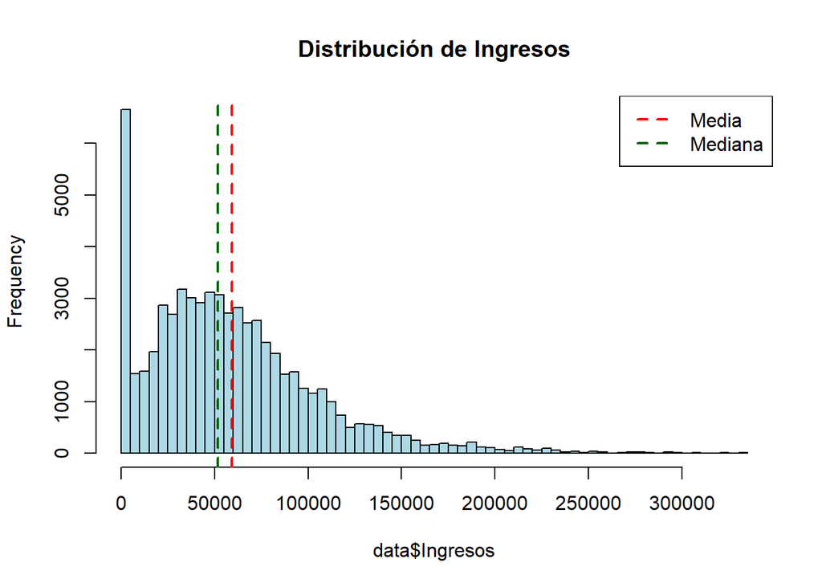

```r
hist(data$Ingresos, main = "Distribución de Ingresos", col = "lightblue", breaks = 50)
abline(v = mean(data$Ingresos, na.rm = TRUE), col = "red", lwd = 2, lty = 2)
abline(v = median(data$Ingresos, na.rm = TRUE), col = "darkgreen", lwd = 2, lty = 2)
legend("topright", legend = c("Media", "Mediana"), col = c("red", "darkgreen"), lty = 2, lwd = 2)
```

`Ingresos` al ser una variable monetaria se hizo un analisis para poder aproximar resultados que fueran coherentes en la cartera, la variable presenta una distribución sesgada (media > mediana, skewness = 1.30), con una tasa de NA relativamente homogénea entre categorías de Trabajo y Educación para usar como mediana condicional.

Se evaluó tambien la hipótesis de que los NA conjuntos en `Trabajo` e `Ingresos` correspondieran a asegurados sin empleo formal: de 4,750 casos con `Trabajo` faltante, solo 273 (5.75%) presentan también `Ingresos` faltante, respaldando parcialmente esta hipótesis únicamente para ese subconjunto específico.

```r
sum(data$ValorDomicilio == 0, na.rm = TRUE)
```

```
## [1] 20266
```

```r
mean(data$ValorDomicilio == 0, na.rm = TRUE) * 100
```

```
## [1] 33.08033
```

```r
mean(data$ValorDomicilio, na.rm = TRUE)
```

```
## [1] 143365.4
```

```r
median(data$ValorDomicilio, na.rm = TRUE)
```

```
## [1] 150872
```

```r
skewness(data$ValorDomicilio, na.rm = TRUE)
```

```
## [1] 0.5720919
```

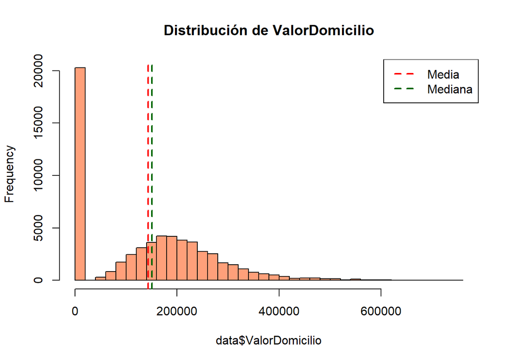

```r
hist(data$ValorDomicilio, main = "Distribución de ValorDomicilio", col = "lightsalmon", breaks = 50)
abline(v = mean(data$ValorDomicilio, na.rm = TRUE), col = "red", lwd = 2, lty = 2)
abline(v = median(data$ValorDomicilio, na.rm = TRUE), col = "darkgreen", lwd = 2, lty = 2)
legend("topright", legend = c("Media", "Mediana"), col = c("red", "darkgreen"), lty = 2, lwd = 2)
```

`ValorDomicilio` es una variable que se debe tratar con cautela por su propio contexto, el 33.08% de los asegurados tiene un valor 0 (no propietarios de vivienda), lo que indica una mezcla de dos subpoblaciones en lugar de una distribución continua pura.

Ante la ausencia de evidencia sobre si los NA corresponden a propietarios o no, se opta por una imputación conservadora respecto al perfil de riesgo asumiendo que los asegurados con ValorDomicilio en 0 no disponen de vivienda propia al momento.

### 2.6 Estrategia de imputación y ejecución

**Resumen de la estrategia adoptada:**

| Variable | Método | Justificación |
| --- | --- | --- |
| AntiguedadTrabajo | Mediana general | NA homogéneo entre categorías de Trabajo (MCAR) |
| Antiguedad | Mediana general | NA homogéneo entre rangos de edad (MCAR) |
| Edad | Mediana condicional por Educación | NA depende del nivel educativo |
| Ingresos | Mediana condicional por Trabajo (0 para casos de sin-empleo evidenciado) | Distribución sesgada; dependencia parcial con Trabajo |
| ValorDomicilio | Mínimo (0) | 33% de no-propietarios; decisión conservadora ante ausencia de evidencia |
| Trabajo | Categoría “Desconocido” / “Sin empleo, No reportado” | Variable categórica; se preserva la falta como información |

```r
data$AntiguedadTrabajo[is.na(data$AntiguedadTrabajo)] <- median(data$AntiguedadTrabajo, na.rm = TRUE)

data <- data %>%
  group_by(Educacion) %>%
  mutate(Edad = ifelse(is.na(Edad), median(Edad, na.rm = TRUE), Edad)) %>%
  ungroup()

data$Antiguedad[is.na(data$Antiguedad)] <- median(data$Antiguedad, na.rm = TRUE)
```

```r
sin_empleo <- is.na(data$Trabajo) & is.na(data$Ingresos)

data$Ingresos[sin_empleo] <- 0
data$Trabajo[sin_empleo] <- "Sin empleo/No reportado"

data <- data %>%
  group_by(Trabajo) %>%
  mutate(Ingresos = ifelse(is.na(Ingresos), median(Ingresos, na.rm = TRUE), Ingresos)) %>%
  ungroup()

data$Trabajo[is.na(data$Trabajo)] <- "Desconocido"

sum(is.na(data$Ingresos))
```

```
## [1] 0
```

Se verificó que ningún grupo de Trabajo careciera de valores observados para el cálculo de la mediana condicional, por lo que la imputación de Ingresos no dejó valores faltantes residuales.

```r
data$ValorDomicilio[is.na(data$ValorDomicilio)] <- 0
```

### 2.7 Comprobación del impacto de la imputación

```r
colSums(is.na(data[, c("Edad", "AntiguedadTrabajo", "Ingresos", "ValorDomicilio", "Trabajo", "Antiguedad")]))
```

```
##              Edad AntiguedadTrabajo          Ingresos    ValorDomicilio
##                 0                 0                 0                 0
##           Trabajo        Antiguedad
##                 0                 0
```

```r
resumen_despues <- data.frame(
  variable = c("Edad", "AntiguedadTrabajo", "Ingresos", "ValorDomicilio", "Antiguedad"),
  media_despues = c(mean(data$Edad), mean(data$AntiguedadTrabajo),
                    mean(data$Ingresos), mean(data$ValorDomicilio),
                    mean(data$Antiguedad)),
  sd_despues = c(sd(data$Edad), sd(data$AntiguedadTrabajo),
                 sd(data$Ingresos), sd(data$ValorDomicilio),
                 sd(data$Antiguedad))
)

comparacion <- merge(resumen_antes, resumen_despues, by = "variable")
comparacion$reduccion_sd_pct <- round((1 - comparacion$sd_despues/comparacion$sd_antes) * 100, 2)
comparacion
```

```
##            variable   media_antes      sd_antes media_despues    sd_despues
## 1        Antiguedad      8.142324      5.708723      8.133154      5.521860
## 2 AntiguedadTrabajo     10.383985      4.182832     10.416738      4.072459
## 3              Edad     44.438245      8.939785     44.437000      8.936490
## 4          Ingresos  59182.640687  46272.111515  58298.595031  45707.134327
## 5    ValorDomicilio 143365.444265 126194.670351 135123.034031 126977.426737
##   reduccion_sd_pct
## 1             3.27
## 2             2.64
## 3             0.04
## 4             1.22
## 5            -0.62
```

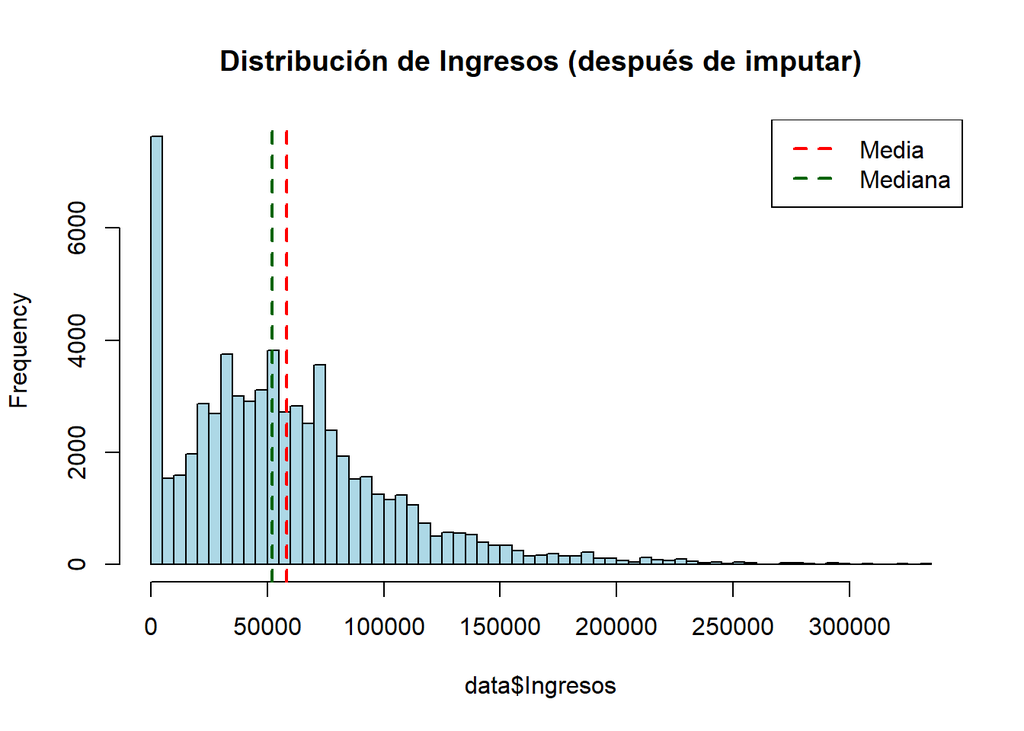

```r
hist(data$Ingresos, main = "Distribución de Ingresos (después de imputar)",
     col = "lightblue", breaks = 50)
abline(v = mean(data$Ingresos), col = "red", lwd = 2, lty = 2)
abline(v = median(data$Ingresos), col = "darkgreen", lwd = 2, lty = 2)
legend("topright", legend = c("Media", "Mediana"), col = c("red", "darkgreen"), lty = 2, lwd = 2)
```

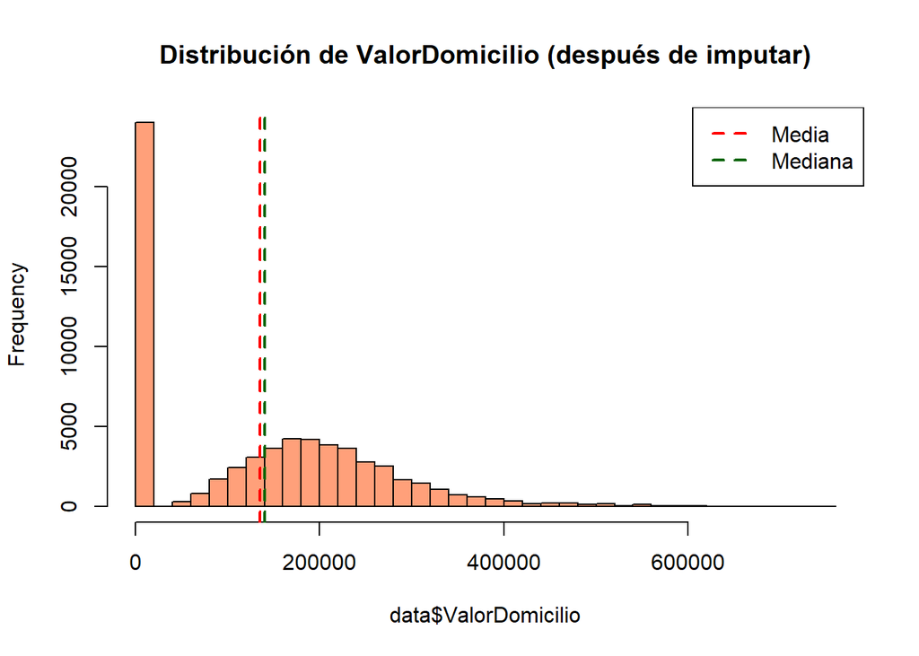

```r
hist(data$ValorDomicilio, main = "Distribución de ValorDomicilio (después de imputar)",
     col = "lightsalmon", breaks = 50)
abline(v = mean(data$ValorDomicilio), col = "red", lwd = 2, lty = 2)
abline(v = median(data$ValorDomicilio), col = "darkgreen", lwd = 2, lty = 2)
legend("topright", legend = c("Media", "Mediana"), col = c("red", "darkgreen"), lty = 2, lwd = 2)
```

Al comparar la desviación estándar antes y después de la imputación, se observa el patrón esperado en cuatro de las cinco variables: una reducción de la variabilidad (entre 0.04% y 3.27%), consistente con el efecto típico de la imputación por mediana.

La variable `ValorDomicilio` constituye la excepción, con un ligero aumento en la desviación estándar (-0.62%), explicado por la naturaleza distinta de su imputación: al usar el valor mínimo (0) en lugar de una medida de tendencia central, y dado que la variable ya presentaba una masa considerable de ceros (33.08%), el efecto refuerza la estructura bimodal de la variable en lugar de concentrarla hacia el centro.

Este resultado es coherente con la decisión metodológica tomada: se priorizó la fundamentación conceptual —evitar asumir propiedad de vivienda sin evidencia— sobre la minimización estadística de la varianza.

## 3. Estandarización categórica y consistencia

Se validan y recodifican las variables binarias `Soltero`, `ColorRojo`, `Suspensiones` y `ConducenHijos` a un formato booleano uniforme, donde 1 (o `TRUE`) identifica el caso afirmativo.

```r
unique(data$Soltero)
```

```
## [1] "No" "Si"
```

```r
unique(data$ColorRojo)
```

```
## [1] "no" "si"
```

```r
unique(data$Suspensiones)
```

```
## [1] "No" "Si"
```

```r
unique(data$ConducenHijos)
```

```
## [1] 0 1 2 3 4
```

```r
data$Soltero <- data$Soltero %in% c("Si", "SI", "si", "Sí", "SÍ", "sí")
data$ColorRojo <- data$ColorRojo %in% c("Si", "SI", "si", "Sí", "SÍ", "sí")
data$Suspensiones <- data$Suspensiones %in% c("Si", "SI", "si", "Sí", "SÍ", "sí")

str(data[, c("Soltero", "ColorRojo", "Suspensiones", "ConducenHijos")])
```

```
## tibble [65,000 × 4] (S3: tbl_df/tbl/data.frame)
##  $ Soltero      : logi [1:65000] FALSE FALSE FALSE FALSE FALSE FALSE ...
##  $ ColorRojo    : logi [1:65000] FALSE FALSE FALSE FALSE FALSE TRUE ...
##  $ Suspensiones : logi [1:65000] FALSE TRUE FALSE FALSE FALSE FALSE ...
##  $ ConducenHijos: num [1:65000] 0 0 0 0 0 0 0 0 1 0 ...
```

Al validar los valores únicos de cada variable, se identificó que `ConducenHijos` no es estrictamente binaria: presenta 5 valores posibles (del 0 al 4), correspondientes al número de hijos del asegurado que conducen el vehículo, en lugar de un simple indicador sí/no.

Dado que esta variable numérica ya explica adecuadamente la magnitud del fenómeno (cuántos hijos conducen, no solo si alguno lo hace), se decide no forzar su conversión a booleano, preservando la información completa para su uso en análisis posteriores donde la magnitud pueda ser relevante.

Las variables `Soltero`, `ColorRojo` y `Suspensiones` quedan estandarizadas como valores lógicos (`TRUE`/`FALSE`), donde `TRUE` identifica de forma consistente el caso afirmativo, independientemente del formato original del texto (mayúscula/minúscula). `ConducenHijos` se conserva en su formato numérico original.

# Fase 2: Manipulación, Agregación y Métricas de Siniestralidad

## 1. Severidad y frecuencia de siniestros por vehículo

Se calculan las métricas de siniestralidad agregadas por Tipo de vehículo y Uso (Comercial vs. Privado): porcentaje de asegurados con al menos un siniestro, frecuencia promedio, cuantía total reclamada y cuantía promedio por siniestro.

```r
resultado_2_1 <- data %>%
  group_by(Tipo, Uso) %>%
  summarise(
    Asegurados = n(),
    Asegurados_con_siniestro = sum(NSiniestros > 0),
    Porcentaje_con_siniestro = mean(NSiniestros > 0) * 100,
    Frecuencia_promedio = mean(NSiniestros),
    Cuantia_total = sum(TCuantia),
    Siniestros_totales = sum(NSiniestros),
    Cuantia_promedio_por_siniestro = ifelse(sum(NSiniestros) > 0,
                                            sum(TCuantia) / sum(NSiniestros), NA),
    .groups = "drop"
  ) %>%
  arrange(Tipo, Uso)

resultado_2_1
```

```
## # A tibble: 11 × 9
##    Tipo      Uso       Asegurados Asegurados_con_sinies…¹ Porcentaje_con_sinie…²
##    <chr>     <chr>          <int>                   <int>                  <dbl>
##  1 Camión    Comercial       5825                    4683                   80.4
##  2 Deportivo Comercial       1451                    1225                   84.4
##  3 Deportivo Privado         6850                    5664                   82.7
##  4 Minivan   Comercial       3503                    2786                   79.5
##  5 Minivan   Privado        11608                    8188                   70.5
##  6 Pickup    Comercial       7308                    5987                   81.9
##  7 Pickup    Privado         3970                    2930                   73.8
##  8 SUV       Comercial       3857                    3193                   82.8
##  9 SUV       Privado        14589                   11528                   79.0
## 10 Van       Comercial       3962                    3270                   82.5
## 11 Van       Privado         2077                    1546                   74.4
## # ℹ abbreviated names: ¹Asegurados_con_siniestro, ²Porcentaje_con_siniestro
## # ℹ 4 more variables: Frecuencia_promedio <dbl>, Cuantia_total <dbl>,
## #   Siniestros_totales <dbl>, Cuantia_promedio_por_siniestro <dbl>
```

```r
# Identificación de los extremos
resultado_2_1[which.max(resultado_2_1$Porcentaje_con_siniestro), ]
```

```
## # A tibble: 1 × 9
##   Tipo      Uso       Asegurados Asegurados_con_siniestro Porcentaje_con_sinie…¹
##   <chr>     <chr>          <int>                    <int>                  <dbl>
## 1 Deportivo Comercial       1451                     1225                   84.4
## # ℹ abbreviated name: ¹Porcentaje_con_siniestro
## # ℹ 4 more variables: Frecuencia_promedio <dbl>, Cuantia_total <dbl>,
## #   Siniestros_totales <dbl>, Cuantia_promedio_por_siniestro <dbl>
```

```r
resultado_2_1[which.max(resultado_2_1$Frecuencia_promedio), ]
```

```
## # A tibble: 1 × 9
##   Tipo      Uso       Asegurados Asegurados_con_siniestro Porcentaje_con_sinie…¹
##   <chr>     <chr>          <int>                    <int>                  <dbl>
## 1 Deportivo Comercial       1451                     1225                   84.4
## # ℹ abbreviated name: ¹Porcentaje_con_siniestro
## # ℹ 4 more variables: Frecuencia_promedio <dbl>, Cuantia_total <dbl>,
## #   Siniestros_totales <dbl>, Cuantia_promedio_por_siniestro <dbl>
```

```r
resultado_2_1[which.max(resultado_2_1$Cuantia_total), ]
```

```
## # A tibble: 1 × 9
##   Tipo  Uso     Asegurados Asegurados_con_siniestro Porcentaje_con_siniestro
##   <chr> <chr>        <int>                    <int>                    <dbl>
## 1 SUV   Privado      14589                    11528                     79.0
## # ℹ 4 more variables: Frecuencia_promedio <dbl>, Cuantia_total <dbl>,
## #   Siniestros_totales <dbl>, Cuantia_promedio_por_siniestro <dbl>
```

```r
resultado_2_1[which.max(resultado_2_1$Cuantia_promedio_por_siniestro), ]
```

```
## # A tibble: 1 × 9
##   Tipo      Uso       Asegurados Asegurados_con_siniestro Porcentaje_con_sinie…¹
##   <chr>     <chr>          <int>                    <int>                  <dbl>
## 1 Deportivo Comercial       1451                     1225                   84.4
## # ℹ abbreviated name: ¹Porcentaje_con_siniestro
## # ℹ 4 more variables: Frecuencia_promedio <dbl>, Cuantia_total <dbl>,
## #   Siniestros_totales <dbl>, Cuantia_promedio_por_siniestro <dbl>
```

El vehículo **Deportivo de uso Comercial** domina tres de las cuatro métricas analizadas: presenta el mayor porcentaje de asegurados con siniestros (84.4%), la mayor frecuencia promedio (1.77 siniestros por asegurado) y la mayor severidad promedio por siniestro ($6,367). La única métrica donde no lidera es la cuantía total acumulada, donde **SUV Privado** encabeza con $119,798,520 — resultado explicado por su mayor volumen de asegurados (14,589, frente a los 1,451 de Deportivo Comercial), no por un mayor riesgo individual.

Un patrón consistente en toda la tabla es que, dentro de cada tipo de vehículo, el uso **Comercial** presenta sistemáticamente un mayor porcentaje de asegurados con siniestro y mayor frecuencia promedio que el uso **Privado** (por ejemplo, Pickup: 81.9% Comercial vs. 73.8% Privado; Van: 82.5% vs. 74.4%). Esto es coherente con la intuición actuarial de que los vehículos de uso comercial están expuestos a mayor kilometraje y horas de circulación, incrementando su exposición al riesgo.

## 2. Análisis de riesgo demográfico y experiencia

Se crean rangos de edad (según la consigna: Joven <30, Adulto 30-55, Senior >55) y de experiencia al volante, y se determina qué segmento presenta el mayor valor acumulado de pérdidas.

```r
data$RangoEdad <- cut(data$Edad,
                      breaks = c(-Inf, 29, 55, Inf),
                      labels = c("Joven", "Adulto", "Senior"))

summary(data$Experiencia)
```

```
##    Min. 1st Qu.  Median    Mean 3rd Qu.    Max.
##   1.000   1.000   4.000   5.225   7.000  25.000
```

```r
data$RangoExperiencia <- cut(data$Experiencia,
                             breaks = quantile(data$Experiencia, probs = c(0, 1/3, 2/3, 1)),
                             labels = c("Baja", "Media", "Alta"),
                             include.lowest = TRUE)
```

Dado que la consigna no especifica los cortes de experiencia, se definieron en base a los terciles reales de la variable (cortes en el percentil 33 y 66), asegurando una distribución objetiva y balanceada en lugar de umbrales arbitrarios.

```r
perdidas_edad <- data %>%
  group_by(RangoEdad) %>%
  summarise(
    Asegurados = n(),
    Siniestros_totales = sum(NSiniestros),
    Perdida_acumulada = sum(TCuantia),
    Reclamo_promedio = mean(TCuantia),
    .groups = "drop"
  ) %>%
  mutate(Participacion_perdida_pct = Perdida_acumulada / sum(Perdida_acumulada) * 100)

perdidas_edad
```

```
## # A tibble: 3 × 6
##   RangoEdad Asegurados Siniestros_totales Perdida_acumulada Reclamo_promedio
##   <fct>          <int>              <dbl>             <dbl>            <dbl>
## 1 Joven           3189               5713          27564761            8644.
## 2 Adulto         54568              88330         446650302            8185.
## 3 Senior          7243              12019          58841573            8124.
## # ℹ 1 more variable: Participacion_perdida_pct <dbl>
```

```r
perdidas_edad$RangoEdad[which.max(perdidas_edad$Perdida_acumulada)]
```

```
## [1] Adulto
## Levels: Joven Adulto Senior
```

El segmento **Adulto** (30-55 años) concentra la mayor pérdida acumulada de la cartera ($446,650,302, equivalente al 83.8% del total), muy por encima de Senior (11.0%) y Joven (5.17%). Sin embargo, este resultado está fuertemente influenciado por el tamaño del grupo: Adulto representa 54,568 de los 65,000 asegurados (84%), por lo que su dominancia en pérdidas acumuladas es, en gran medida, un efecto de volumen y no necesariamente de mayor riesgo individual. De hecho, al observar el reclamo promedio por asegurado, los tres grupos son sorprendentemente similares (Joven: $8,644; Adulto: $8,185; Senior: $8,124) — el grupo Joven tiene, de hecho, el reclamo promedio más alto de los tres, sugiriendo un perfil de riesgo per cápita ligeramente mayor a pesar de representar la menor pérdida acumulada total.

```r
severidad_educacion <- data %>%
  group_by(Educacion) %>%
  summarise(
    Asegurados = n(),
    Siniestros_totales = sum(NSiniestros),
    Cuantia_total = sum(TCuantia),
    .groups = "drop"
  ) %>%
  mutate(Severidad_promedio = ifelse(Siniestros_totales > 0,
                                     Cuantia_total / Siniestros_totales, NA))

severidad_educacion
```

```
## # A tibble: 5 × 5
##   Educacion Asegurados Siniestros_totales Cuantia_total Severidad_promedio
##   <chr>          <int>              <dbl>         <dbl>              <dbl>
## 1 Bachiller       9730              15746      81547177              5179.
## 2 Master         12348              19359     101007744              5218.
## 3 PhD             5546               8703      43906323              5045.
## 4 Superior       18014              30083     146765859              4879.
## 5 Técnico        19362              32171     159829533              4968.
```

No se observa una diferencia considerable en la severidad promedio por siniestro entre niveles educativos: el rango va de $4,879 (Superior) a $5,218 (Master), una diferencia de apenas 6.9%. Esto sugiere que el nivel educativo no es un factor determinante de la severidad de los siniestros en esta cartera.

## 3. Razón vehículo-ingreso e infracciones

Se calcula la razón entre el valor del vehículo y el ingreso del asegurado, y se analiza su relación con las suspensiones de licencia y la frecuencia de accidentes en zonas urbanas y rurales.

```r
data$Razon <- ifelse(data$Ingresos > 0, data$ValVehiculo / data$Ingresos, NA)

sum(is.na(data$Razon))
```

```
## [1] 6426
```

Se identificaron 6,426 registros donde la razón vehículo-ingreso no pudo calcularse, correspondientes a asegurados con `Ingresos = 0`.

```r
resumen_zona_suspensiones <- data %>%
  group_by(Zona, Suspensiones) %>%
  summarise(
    Asegurados = n(),
    Razon_promedio = mean(Razon, na.rm = TRUE),
    Razon_mediana = median(Razon, na.rm = TRUE),
    Frecuencia_promedio = mean(NSiniestros),
    Siniestros_totales = sum(NSiniestros),
    .groups = "drop"
  )

resumen_zona_suspensiones
```

```
## # A tibble: 4 × 7
##   Zona  Suspensiones Asegurados Razon_promedio Razon_mediana Frecuencia_promedio
##   <chr> <lgl>             <int>          <dbl>         <dbl>               <dbl>
## 1 Rural FALSE              6513          1.54          0.309               0.891
## 2 Rural TRUE                667          0.671         0.264               1.28
## 3 Urba… FALSE             49039          0.998         0.248               1.71
## 4 Urba… TRUE               8781          0.547         0.252               1.75
## # ℹ 1 more variable: Siniestros_totales <dbl>
```

```r
frecuencia_zona <- data %>%
  group_by(Zona) %>%
  summarise(
    Asegurados = n(),
    Siniestros_totales = sum(NSiniestros),
    Frecuencia_promedio = mean(NSiniestros),
    .groups = "drop"
  )

frecuencia_zona
```

```
## # A tibble: 2 × 4
##   Zona   Asegurados Siniestros_totales Frecuencia_promedio
##   <chr>       <int>              <dbl>               <dbl>
## 1 Rural        7180               6662               0.928
## 2 Urbano      57820              99400               1.72
```

Al comparar la razón promedio entre asegurados con y sin suspensiones de licencia, se observa un patrón contraintuitivo: en ambas zonas, los asegurados **sin** suspensiones presentan una razón vehículo-ingreso más alta que los que **sí** tienen suspensiones (Rural: 1.54 vs. 0.671; Urbano: 0.998 vs. 0.547). Es decir, quienes compran vehículos más costosos en relación a su ingreso no son, en este dataset, los que más suspensiones acumulan.

Respecto a la zona geográfica, la frecuencia promedio de siniestros es notablemente mayor en **Urbano** (1.72) que en **Rural** (0.928) — casi el doble—, consistente con la mayor densidad de tráfico y exposición en zonas urbanas.

```r
data$Suspensiones_num <- as.numeric(data$Suspensiones)

cor(data[, c("Razon", "Suspensiones_num", "NSiniestros")],
    use = "complete.obs", method = "pearson")
```

```
##                         Razon Suspensiones_num NSiniestros
## Razon             1.000000000     -0.007862609 -0.01078067
## Suspensiones_num -0.007862609      1.000000000  0.02396512
## NSiniestros      -0.010780675      0.023965117  1.00000000
```

```r
cor(data[, c("Razon", "Suspensiones_num", "NSiniestros")],
    use = "complete.obs", method = "spearman")
```

```
##                         Razon Suspensiones_num NSiniestros
## Razon             1.000000000     -0.000539543 0.003219023
## Suspensiones_num -0.000539543      1.000000000 0.030365340
## NSiniestros       0.003219023      0.030365340 1.000000000
```

```r
data %>%
  group_by(Zona) %>%
  summarise(
    Pearson_Razon_Frecuencia = cor(Razon, NSiniestros, use = "complete.obs", method = "pearson"),
    Spearman_Razon_Frecuencia = cor(Razon, NSiniestros, use = "complete.obs", method = "spearman"),
    .groups = "drop"
  )
```

```
## # A tibble: 2 × 3
##   Zona   Pearson_Razon_Frecuencia Spearman_Razon_Frecuencia
##   <chr>                     <dbl>                     <dbl>
## 1 Rural                  -0.0192                    -0.0355
## 2 Urbano                 -0.00845                    0.0289
```

En términos descriptivos, ni la razón vehículo-ingreso ni las suspensiones de licencia muestran una asociación relevante con la frecuencia de siniestros en este análisis exploratorio; el factor que sí muestra una diferencia clara y consistente es la zona geográfica (urbano vs. rural), que prácticamente duplica la frecuencia promedio de siniestros.

# Fase 3: Visualización de Datos e Insights Visuales

## 1. Distribución de la cuantía de reclamaciones

Se construye un histograma de `TCuantia` para la población siniestrada (`NSiniestros > 0`), aplicando una transformación logarítmica `log(1 + TCuantia)` para mitigar el sesgo a la derecha característico de las variables monetarias.

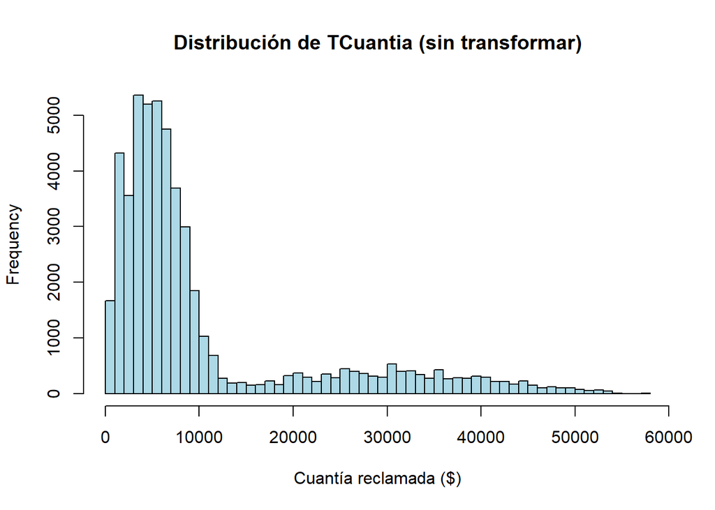

```r
siniestrados <- data %>% filter(NSiniestros > 0)

hist(siniestrados$TCuantia,
     main = "Distribución de TCuantia (sin transformar)",
     xlab = "Cuantía reclamada ($)", col = "lightblue", breaks = 50)
```

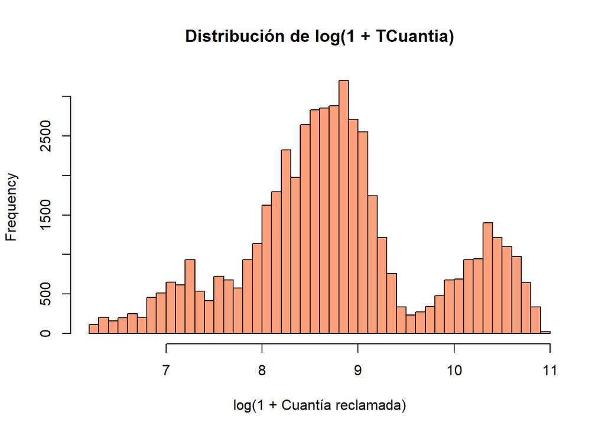

```r
hist(log(1 + siniestrados$TCuantia),
     main = "Distribución de log(1 + TCuantia)",
     xlab = "log(1 + Cuantía reclamada)", col = "lightsalmon", breaks = 50)
```

```r
# Cuantificación de la asimetría antes y después de la transformación
skewness(siniestrados$TCuantia)
```

```
## [1] 1.801549
```

```r
skewness(log(1 + siniestrados$TCuantia))
```

```
## [1] 0.1242303
```

La distribución original de TCuantia presenta un fuerte sesgo a la derecha, con la mayoría de las reclamaciones concentradas por debajo de 10,000 y una cola extendida de reclamaciones de alto valor que se dispersa hasta cerca de 60,000.

La asimetría (skewness) de TCuantia en la población siniestrada es de 1.80, confirmando el fuerte sesgo a la derecha observado visualmente. Tras la transformación logarítmica, la asimetría se reduce a 0.12 — una disminución del 93%, cuantificando de forma objetiva la efectividad de la transformación para aproximar la distribución a una forma simétrica.

La transformación logarítmica revela una estructura que el histograma original ocultaba: la distribución es visiblemente bimodal, con un pico principal alrededor de log≈8.7 (equivalente a montos cercanos a $5,000-$6,000) y un segundo pico más pequeño alrededor de log≈10.3 (montos cercanos a $30,000).

Esto sugiere la existencia de dos subpoblaciones de severidad distintas dentro de la cartera —posiblemente siniestros menores (daños leves, reparaciones) frente a siniestros mayores (pérdida total, daños graves)— en lugar de una única distribución continua homogénea.

## 2. Comparación territorial y tipo de Uso

Se construye un boxplot que contrapone el costo acumulado de siniestros entre uso Comercial y Privado, segmentado por Zona (Urbano vs. Rural).

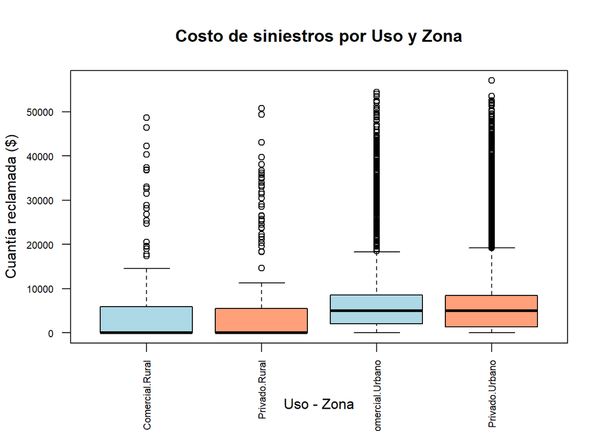

```r
costo_por_asegurado <- data %>%
  group_by(Zona, Uso) %>%
  summarise(Costo_total = sum(TCuantia), .groups = "drop")

boxplot(TCuantia ~ Uso * Zona, data = data,
        main = "Costo de siniestros por Uso y Zona",
        xlab = "Uso - Zona", ylab = "Cuantía reclamada ($)",
        col = c("lightblue", "lightsalmon"),
        las = 2, cex.axis = 0.7)
```

```r
costo_por_asegurado
```

```
## # A tibble: 4 × 3
##   Zona   Uso       Costo_total
##   <chr>  <chr>           <dbl>
## 1 Rural  Comercial    13858165
## 2 Rural  Privado      20752105
## 3 Urbano Comercial   198014708
## 4 Urbano Privado     300431658
```

Al analizar el costo acumulado total, la diferencia entre zonas es contundente: la zona Urbana concentra $498,446,366 en costo total (Comercial: $198,014,708 + Privado: $300,431,658), frente a apenas $34,610,270 en la zona Rural (Comercial: $13,858,165 + Privado: $20,752,105) — la zona Urbana representa aproximadamente el 93.5% del costo total de siniestros de toda la cartera.

Dentro de cada zona, el uso Privado acumula un costo total mayor que el Comercial (Urbano: $300.4M vs. $198.0M; Rural: $20.8M vs. $13.9M), lo cual es explicado principalmente por el mayor volumen de asegurados en uso Privado, más que por una mayor severidad individual —de hecho, en la Fase 2.1 se observó que los segmentos Comerciales tienden a tener mayor frecuencia y severidad promedio por asegurado individual—.

## 3. Matriz de infracciones y perfil familiar

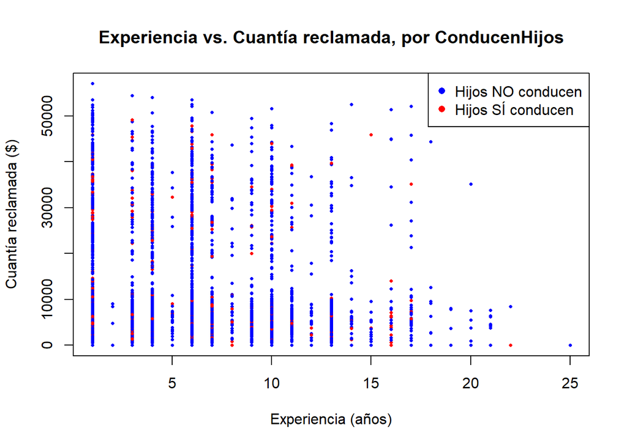

```r
data$ConducenHijos_flag <- ifelse(data$ConducenHijos > 0, "Sí", "No")

plot(data$Experiencia, data$TCuantia,
     col = ifelse(data$ConducenHijos_flag == "Sí", "red", "blue"),
     pch = 16, cex = 0.5,
     main = "Experiencia vs. Cuantía reclamada, por ConducenHijos",
     xlab = "Experiencia (años)", ylab = "Cuantía reclamada ($)")
legend("topright", legend = c("Hijos NO conducen", "Hijos SÍ conducen"),
       col = c("blue", "red"), pch = 16)
```

El gráfico de dispersión no muestra una relación visual clara entre la experiencia del conductor y la cuantía reclamada: los montos reclamados se distribuyen de forma similar a lo largo de todo el rango de experiencia (1 a 25 años), sin una tendencia descendente o ascendente evidente.

Se observa, sin embargo, una mayor densidad de observaciones en el rango de experiencia baja (1-10 años), consistente con la distribución general de la variable Experiencia en la cartera. La diferenciación por color (hijos que conducen, en rojo) no revela un patrón visual distintivo frente a los casos donde los hijos no conducen (azul) — los puntos rojos se distribuyen de forma dispersa entre los azules, sin concentrarse en una zona particular del gráfico.

Esta ausencia de patrón visual es consistente con las correlaciones débiles encontradas en la Fase 2 entre variables relacionadas con el comportamiento de riesgo, y refuerza el hallazgo del heatmap: Suspensiones, no ConducenHijos ni Experiencia, es el factor con la asociación más clara y consistente respecto a la severidad de los reclamos.

```r
heatmap_data <- data %>%
  group_by(Suspensiones, ConducenHijos) %>%
  summarise(
    Asegurados = n(),
    Reclamo_promedio = mean(TCuantia),
    .groups = "drop"
  )

heatmap_data
```

```
## # A tibble: 10 × 4
##    Suspensiones ConducenHijos Asegurados Reclamo_promedio
##    <lgl>                <dbl>      <int>            <dbl>
##  1 FALSE                    0      48552            5461.
##  2 FALSE                    1       4512            5783.
##  3 FALSE                    2       2031            6080.
##  4 FALSE                    3        446            4772.
##  5 FALSE                    4         11            4327.
##  6 TRUE                     0       7954           24257.
##  7 TRUE                     1       1057           24189.
##  8 TRUE                     2        310           20423.
##  9 TRUE                     3        112           19224.
## 10 TRUE                     4         15           21140.
```

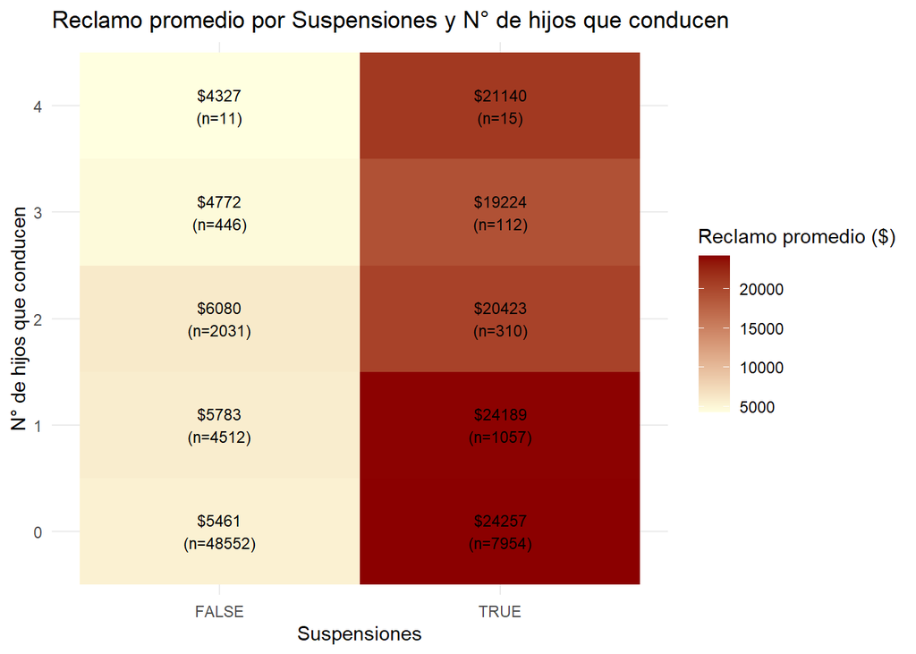

```r
ggplot(heatmap_data, aes(x = factor(Suspensiones), y = factor(ConducenHijos), fill = Reclamo_promedio)) +
  geom_tile() +
  geom_text(aes(label = paste0("$", round(Reclamo_promedio), "\n(n=", Asegurados, ")")),
            size = 3, color = "black") +
  scale_fill_gradient(low = "lightyellow", high = "darkred") +
  labs(title = "Reclamo promedio por Suspensiones y N° de hijos que conducen",
       x = "Suspensiones", y = "N° de hijos que conducen", fill = "Reclamo promedio ($)") +
  theme_minimal()
```